# Fourth Week: Hypothesis Testing

TIMSS Analysis

Mobin-Asri 93101938

2018-03-10 03:19:56

```r
library(ggplot2)
library(highcharter)
library(readr)
library(dplyr)
library(ggpubr)
```

```r
#School Questionare
bcg = read_rds("../Data/bcg.rds")

#Math Teacher Questionare
btm = read_rds("../Data/btm.rds")

#Science Teacher Questionare
#bts = read_rds("../Data/bts.rds")

#Student
bsg = read_rds("../Data/bsg.rds")

#Student Teacher
bst = read_rds("../Data/bst.rds")

## Acheivement
#bsa = read_rds("../Data/bsa.rds")
```

۱. میران رضایت معلمان در پیشرفت تحصیلی دانش آموزان موثر است.

سوال ۱۰ شامل مواردی است که به میزان رضایت معلم ها از شغلشان اشاره دارد.

```r
idx = colnames(btm) %>% grepl(x=.,pattern = "btbg10")
Q10=colnames(btm)[idx]
```

برای هر دانش آموز به ۵ روش نمره برای ارزیابی سواد ریاضی آن ها محاسبه شده است.

نام این ستون ها را پیدا می کنیم.

```r
idx = colnames(bsg) %>% grepl(x=.,pattern = "bsmmat")
math=colnames(bsg)[idx]
```

در سوال شماره ۱۰ که مربوط به رضایت معلمان است گزینه ها به این صورت است که با افزایش شماره گزینه میزان رضایت کاهش می یابد.

از شماره گزینه ی علامت خورده توسط معلم میانگین می گیریم.

```r
btm$Satis <- btm %>% subset(select = Q10) %>%  rowMeans(na.rm = T)

btm %>%
  select(idcntry,idteach,Satis) -> teacher_satis_m
```

از طریق دیتای bst می توان معلم های هر دانش آموز را پیدا کرد.

```r
bst %>%
  select(idcntry,idstud,idteach,math) -> stu_teach
```

اطلاعات هر دانش آموز را با معلم های او در سطر های متناظر قرار می دهیم.

```r
stu_teach %>%
  inner_join(teacher_satis_m,by=c("idcntry","idteach")) -> joined_stu_teach
```

معلم هارا بر اساس میزان رضایت به سه دسته A,B,C تقسیم می کنیم.

```r
joined_stu_teach %>%
  mutate(ScoreMath=(bsmmat01+bsmmat02+bsmmat03+bsmmat04+bsmmat05)/5 ) %>%
   mutate(Satis_level = ifelse(Satis > 3.25 , "C",
                               ifelse(Satis > 1.75, "B","A"))) -> Stu_Satis
```

فرض صفر: بین میانگین نمرات دانش آموزان این سه دسته معلم تفاوتی وجود ندارد. برای تست کردن این فرض صفر از آزمون آنووا استفاده می کنیم.

طبق نتیجه ی آزمون آنووا می توان فرض صفر را رد کرد.

```r
aov(formula = ScoreMath ~ Satis_level, data = Stu_Satis) -> fit
summary.aov(fit)
```

```
##                 Df    Sum Sq Mean Sq F value Pr(>F)
## Satis_level      2 9.150e+06 4574943   424.9 <2e-16 ***
## Residuals   318207 3.427e+09   10768
## ---
## Signif. codes:  0 '***' 0.001 '**' 0.01 '*' 0.05 '.' 0.1 ' ' 1
## 20057 observations deleted due to missingness
```

تصویرسازی

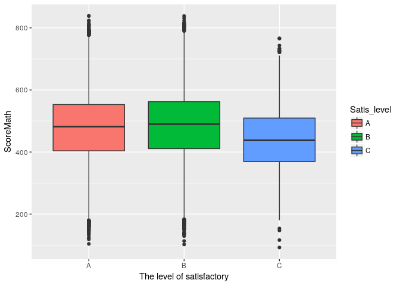

```r
subset(Stu_Satis, !is.na(Satis_level)) %>%
  ggplot(aes(x =Satis_level,y=ScoreMath,fill=Satis_level),na.rm=T)+
  geom_boxplot()+xlab("The level of satisfactory")+ylab("ScoreMath")
```

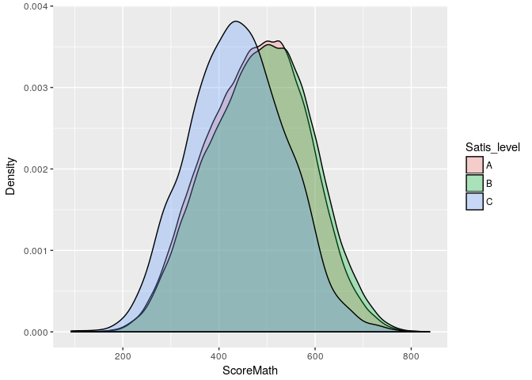

```r
subset(Stu_Satis, !is.na(Satis_level)) %>%
  ggplot(aes(x =ScoreMath,fill=Satis_level),na.rm=T)+
  geom_density(alpha=0.3)+xlab("ScoreMath")+ylab("Density")
```

```r
subset(Stu_Satis, !is.na(Satis_level)) -> t

hcboxplot(x = t$ScoreMath, var = t$Satis_level, name = "length")
```

[interactive chart not shown]

```r
hchart(density(t$ScoreMath[t$Satis_level=="A"]), area = TRUE, name="A") %>%
  hc_add_series(density(t$ScoreMath[t$Satis_level=="B"]), area = TRUE, name="B") %>%
  hc_add_series(density(t$ScoreMath[t$Satis_level=="C"]), area = TRUE , name="C")
```

[interactive chart not shown]

۲. والدینی که تحصیلات بیشتری دارند دارای فرزندان موفق تری می باشند.

سوال ۷ پرسشنامه ی دانش آموز مربوط به تحصیلات پدر و مادر است. شماره ی گزینه به صورت افزایشی با میزان تحصیلات عالی تر تغییر می کند پس هرچه شماره گزینه ی علامت خورده بزرگ تر باشد میزان تحصیلات والدین هم بیشتر است.

بر اساس میانگین تحصیلات پدر و مادر نمرات به سه دسته Edu_A,Edu_B,Edu_C تقسیم می شوند.

```r
bsg %>% select(idcntry,idstud,Mother=bsbg07a,Father=bsbg07b,math) %>%
  mutate(ScoreMath=(bsmmat01+bsmmat02+bsmmat03+bsmmat04+bsmmat05)/5 ,
         edu=(Mother+Father) /2) %>%
  mutate(Edu_level = ifelse(edu >= 8 , "Edu_A",
                            ifelse(edu > 5, "Edu_B","Edu_C"))) -> parent_edu
```

فرض صفر آن است که میانگین نمرات ریاضی دانش آموزان این سه دسته تفاوت معنا داری ندارند.

بر اساس نتایج حاصل از آزمون آنووا این فرض صفر را می توان رد کرد.

```r
aov(formula = ScoreMath ~ Edu_level, data = parent_edu) -> fit
summary.aov(fit)
```

```
##                 Df    Sum Sq  Mean Sq F value Pr(>F)
## Edu_level        2 1.495e+08 74768129    7098 <2e-16 ***
## Residuals   268770 2.831e+09    10533
## ---
## Signif. codes:  0 '***' 0.001 '**' 0.01 '*' 0.05 '.' 0.1 ' ' 1
## 11357 observations deleted due to missingness
```

تصویرسازی

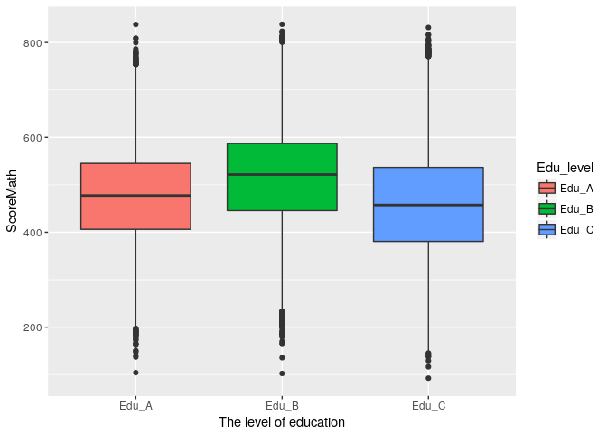

```r
subset(parent_edu, !is.na(Edu_level)) %>%
  ggplot(aes(x = Edu_level,y = ScoreMath,fill=Edu_level),na.rm=T) +
  geom_boxplot()+xlab("The level of education")+ylab("ScoreMath")
```

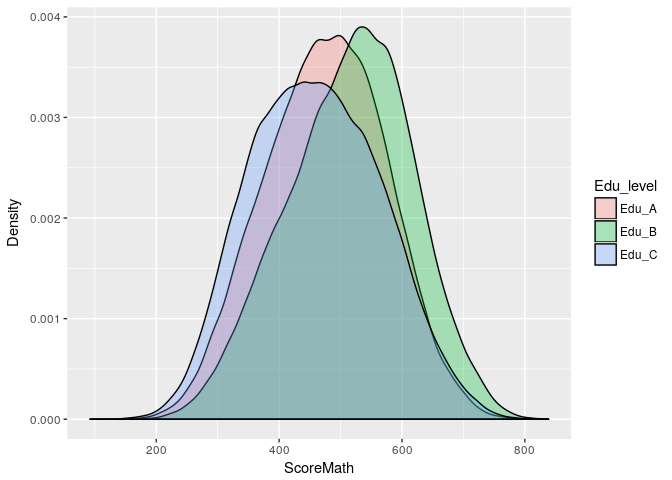

```r
subset(parent_edu, !is.na(Edu_level)) %>%
  ggplot(aes(x =ScoreMath,fill=Edu_level),na.rm=T)+
  geom_density(alpha=0.3)+xlab("ScoreMath")+ylab("Density")
```

```r
subset(parent_edu, !is.na(Edu_level)) -> t

hcboxplot(x = t$ScoreMath, var = t$Edu_level, name = "length")
```

[interactive chart not shown]

```r
hchart(density(t$ScoreMath[t$Edu_level=="Edu_A"]), area = TRUE, name="A") %>%
  hc_add_series(density(t$ScoreMath[t$Edu_level=="Edu_B"]), area = TRUE, name="B") %>%
  hc_add_series(density(t$ScoreMath[t$Edu_level=="Edu_C"]), area = TRUE , name="C")
```

[interactive chart not shown]

۳. امکانات رفاهی در خانه موجب پیشرفت تحصیلی می گردد.

سوال ۶ پرسشنامه ی دانش آموز شامل تعدادی وسیله ی رفاهی و سرگرمی در منزل می شود وجود آنها با بله و خیر پاسخ داده می شود.

مجموع مواردی که بله پاسخ داده شده است معیار مناسبی برای میزان رفاه دانش آموز در منزل است.

```r
idx = colnames(bsg) %>% grepl(x=.,pattern = "bsbg06")
luxury=colnames(bsg)[idx]
```

```r
bsg=as.tbl(bsg)
bsg %>% select(idcntry,idstud,luxury,math) %>%
  mutate_at(luxury,funs(.==1)) -> stu_lux

stu_lux$ScoreMath=rowMeans(stu_lux[,math],na.rm=T)
stu_lux$lux_sum=rowSums(stu_lux[,luxury],na.rm=T)
```

بر اساس تعداد پاسخ های بله به موارد مطرح شده در سوال ۶ دانش آموزان از نظر رفاه در سه سطح Lux_A,Lux_B,Lux_C قرار گرفتند.

```r
stu_lux %>% mutate(lux_level = ifelse(lux_sum >= 8 , "Lux_A",
                          ifelse(lux_sum > 5, "Lux_B","Lux_C"))) -> stu_lux
```

فرض صفر آن است که میانگین نمرات ریاضی دانش آموزان این سه دسته تفاوت معنا داری ندارند.

بر اساس نتایج حاصل از آزمون آنووا این فرض صفر را می توان رد کرد.

```r
aov(formula = ScoreMath ~ lux_level, data = stu_lux) -> fit
summary.aov(fit)
```

```
##                 Df    Sum Sq   Mean Sq F value Pr(>F)
## lux_level        2 2.169e+08 108464727   10363 <2e-16 ***
## Residuals   280127 2.932e+09     10466
## ---
## Signif. codes:  0 '***' 0.001 '**' 0.01 '*' 0.05 '.' 0.1 ' ' 1
```

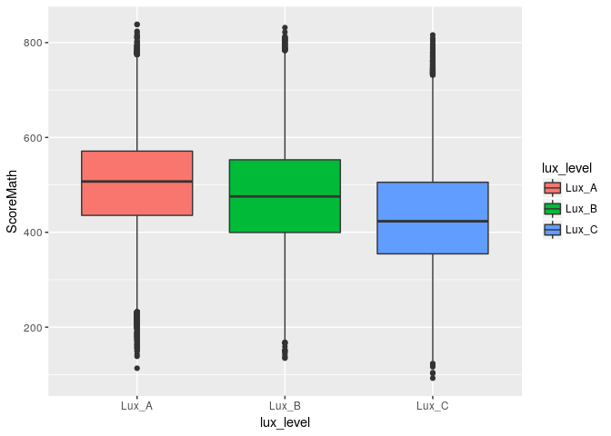

```r
subset(stu_lux, !is.na(stu_lux$lux_level)) %>%
  ggplot(aes(x =lux_level,y=ScoreMath ,fill=lux_level),na.rm=T)+
  geom_boxplot()
```

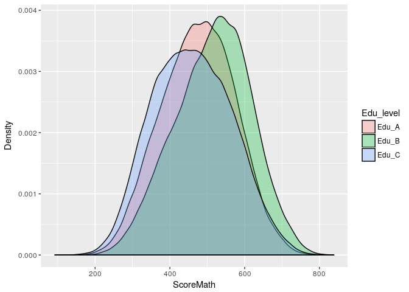

```r
subset(parent_edu, !is.na(Edu_level)) %>%
  ggplot(aes(x =ScoreMath,fill=Edu_level),na.rm=T)+
  geom_density(alpha=0.3)+xlab("ScoreMath")+ylab("Density")
```

```r
subset(parent_edu, !is.na(Edu_level)) -> t

hcboxplot(x = t$ScoreMath, var = t$Edu_level, name = "length")
```

[interactive chart not shown]

```r
hchart(density(t$ScoreMath[t$Edu_level=="Edu_A"]), area = TRUE, name="A") %>%
  hc_add_series(density(t$ScoreMath[t$Edu_level=="Edu_B"]), area = TRUE, name="B") %>%
  hc_add_series(density(t$ScoreMath[t$Edu_level=="Edu_C"]), area = TRUE , name="C")
```

[interactive chart not shown]

۴. محیط آرام مدرسه نقش مهمی در پیشرفت تحصیلی دارد.

سوال ۱۵ پرسشنامه ی دانش آموزان شامل مواردی مبتنی بر میزان امنیت و آرامش و رضایت دانش آموز در محیط مدرسه می باشد.

گزینه های این سوال به صورت افزایش میزان تنش و نارضایتی دانش آموز را نشان می دهد.

```r
idx = colnames(bsg) %>% grepl(x=.,pattern = "bsbg15")
school=colnames(bsg)[idx]
```

```r
bsg=as.tbl(bsg)
bsg %>% select(idcntry,idstud,school,math) -> stu_sch
```

```r
stu_sch$ScoreMath=rowMeans(stu_sch[,math],na.rm=T)
stu_sch$sch_safe=rowMeans(stu_sch[,school],na.rm=T)
```

بر همین اساس مدرسه را به دو محیط امن و ناامن تقسیم کردیم.

```r
stu_sch %>%
  mutate(sch_level = ifelse(sch_safe > 3.25 , "Unsafe","Safe")) -> stu_sch
```

فرض صفر ما در اینجا آن است که میانگین نمرات ریاضی دانش آموزان این دو دسته مدرسه تفاوت چندانی ندارند.

از آن جایی که دو دسته داده داریم می توانیم از تست t استفاده کنیم.

```r
stu_sch %>% t.test(ScoreMath ~ sch_level,data=.)
```

```
##
##  Welch Two Sample t-test
##
## data:  ScoreMath by sch_level
## t = 31.544, df = 5575.2, p-value < 2.2e-16
## alternative hypothesis: true difference in means is not equal to 0
## 95 percent confidence interval:
##  40.32505 45.66936
## sample estimates:
##   mean in group Safe mean in group Unsafe
##             478.2013             435.2041
```

تصویر سازی

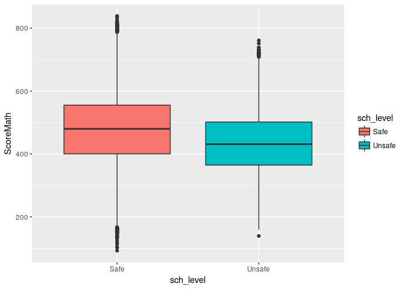

```r
subset(stu_sch, !is.na(sch_level)) %>%
  ggplot(aes(x =sch_level,y=ScoreMath,fill=sch_level),na.rm=T)+
  geom_boxplot()
```

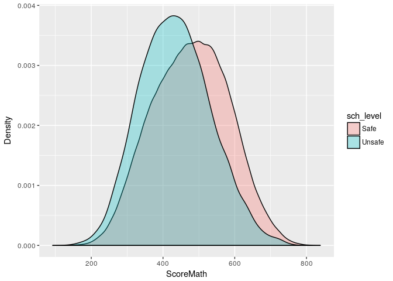

```r
subset(stu_sch, !is.na(sch_level)) %>%
  ggplot(aes(x =ScoreMath,fill=sch_level),na.rm=T)+
  geom_density(alpha=0.3)+xlab("ScoreMath")+ylab("Density")
```

```r
subset(stu_sch, !is.na(sch_level)) -> t

hcboxplot(x = t$ScoreMath, var = t$sch_level, name = "length")
```

[interactive chart not shown]

```r
hchart(density(t$ScoreMath[t$sch_level=="Safe"]), area = TRUE, name="Safe") %>%
  hc_add_series(density(t$ScoreMath[t$sch_level=="Unsafe"]), area = TRUE, name="Unsafe")
```

[interactive chart not shown]

۵. معلمان با تحصیلات بالاتر یا تجربه بیشتر دانش آموزان موفق تری تربیت می کنند.

اولین سوال پرسشنامه معلم ها درباره سابقه ی تدریس آن هاست.

نمرات دانش آموزان براساس سابقه تدریس معلم ها به ۳ دسته A,B,C تقسیم شده اند که A مربوط به سابقه تدریس بالا می باشد.

```r
btm %>%
  select(idcntry,idteach,btbg01) -> teacher_years_m

bst %>%
  select(idcntry,idstud,idteach) -> stu_teach
```

اطلاعات معلم را در کنار اطلاعات دانش آموز قرار می دهیم.

```r
stu_teach %>%
  inner_join(teacher_years_m,by=c("idcntry","idteach")) -> joined_stu_teach
```

نمرات دانش آموزان براساس سابقه تدریس معلم ها به ۳ دسته A,B,C تقسیم شده اند که A مربوط به سابقه تدریس بالا می باشد.

```r
joined_stu_teach %>%
  mutate(exp_level = ifelse(btbg01 > 30 , "A",
                            ifelse(btbg01 > 20, "B","C"))) -> stu_teach_years
```

سوال ۴ پرسشنامه معلم ها مربوط به میزان تحصیلات آنها ست.

```r
btm %>%
  select(idcntry,idteach,edu=btbg04) -> teacher_edu_m
teacher_edu_m$edu=as.factor(teacher_edu_m$edu)
```

اطلاعات معلم را در کنار اطلاعات دانش آموز قرار می دهیم.

```r
bst %>%
  select(idcntry,idstud,idteach,math) -> stu_teach
stu_teach %>%
  inner_join(teacher_edu_m,by=c("idcntry","idteach")) -> stu_teach_edu
```

اطلاعات مربوط به سابقه تدریس و میزان تحصیلات را در کنار هم قرار می دهیم.

```r
stu_teach_edu %>%
  inner_join(stu_teach_years,by=c("idcntry","idteach","idstud")) -> stu_edu_year
```

فرض صفر ما آن است که میانگین نمرات دانش آموزان در دسته های ایجاد شده براساس میزان تحصیلات و سابقه تدریس تفاوت ندارد. از آنجایی که تاثیر دوعامل باید بررسی شود از تست آنووا دو طرفه استفاده می کنیم

```r
stu_edu_year$ScoreMath=rowMeans(stu_edu_year[,math],na.rm=T)

aov(formula = ScoreMath ~ exp_level + edu , data = stu_edu_year) -> fit
summary.aov(fit)
```

```
##                 Df    Sum Sq  Mean Sq F value Pr(>F)
## exp_level        2 1.006e+07  5029473   543.4 <2e-16 ***
## edu              6 1.649e+08 27482133  2969.4 <2e-16 ***
## Residuals   405458 3.753e+09     9255
## ---
## Signif. codes:  0 '***' 0.001 '**' 0.01 '*' 0.05 '.' 0.1 ' ' 1
## 50672 observations deleted due to missingness
```

تصویرسازی

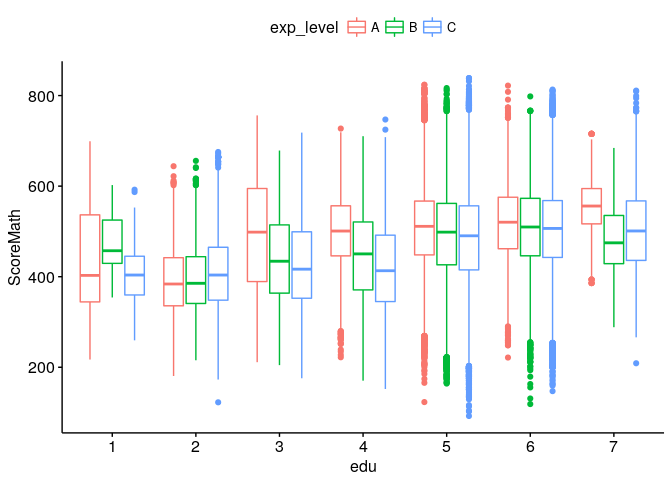

```r
subset(stu_edu_year , !is.na(edu) & !is.na(exp_level)) %>%
  ggboxplot(., x = "edu", y = "ScoreMath", color = "exp_level")
```

۷. تغذیه دانش آموزان نقش اساسی در یادگیری آنها دارد.

برای بررسی تاثیر تغذیه دانش آموزان روی نمره آنها از پرسش مربوط به صبحانه استفاده می کنیم.

```r
bsg %>% select(idcntry,idstud,Breakfast=bsbg12,math) %>%
  mutate(ScoreMath=(bsmmat01+bsmmat02+bsmmat03+bsmmat04+bsmmat05)/5) %>%
  mutate(food_level = ifelse(Breakfast <=2 , "Good","Bad")) -> stu_breakfast
```

دانش آموزان را از نظر تغذیه به دو دسته Good,Bad تقسیم کردیم.

فرض صفر در اینجا آن است که میزان مصرف صبحانه در نمره ی دانش آموزان بی تاثیر است.

با توجه به نتایج t-test فرض صفر را می توان رد کرد.

```r
stu_breakfast %>% t.test(ScoreMath ~ food_level,data=.)
```

```
##
##  Welch Two Sample t-test
##
## data:  ScoreMath by food_level
## t = -69.563, df = 208920, p-value < 2.2e-16
## alternative hypothesis: true difference in means is not equal to 0
## 95 percent confidence interval:
##  -29.40966 -27.79780
## sample estimates:
##  mean in group Bad mean in group Good
##           458.8254           487.4291
```

تصویر سازی

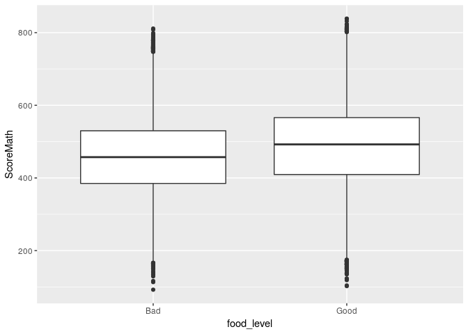

```r
subset(stu_breakfast, !is.na(food_level)) %>%
  ggplot(aes(x =food_level,y=ScoreMath),na.rm=T)+
  geom_boxplot()
```

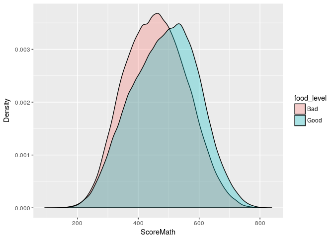

```r
subset(stu_breakfast, !is.na(food_level)) %>%
  ggplot(aes(x =ScoreMath,fill=food_level),na.rm=T)+
  geom_density(alpha=0.3)+xlab("ScoreMath")+ylab("Density")
```

```r
subset(stu_breakfast, !is.na(food_level)) -> t

hcboxplot(x = t$ScoreMath, var = t$food_level, name = "length")
```

[interactive chart not shown]

```r
hchart(density(t$ScoreMath[t$food_level=="Good"]), area = TRUE, name="Good") %>%
  hc_add_series(density(t$ScoreMath[t$food_level=="Bad"]), area = TRUE, name="Bad")
```

[interactive chart not shown]

۸. مدارس با امکانات بیشتر دارای عملکرد بهتری می باشند.

سوال ۱۳ موجود در پرسشنامه مدرسه شامل موارد مربوط به امکانات مدرسه می باشد.

```r
idx = colnames(bcg) %>% grepl(x=.,pattern = "bcbg13a")
sch_facility=colnames(bcg)[idx]
```

جمع موارد مطرح شده در این سوال معیار مناسبی برای میزان امکانات مدرسه است.

مدرسه ها را از نظر امکانات به دو دسته Low level , High level تقسیم می کنیم.

```r
bcg %>% select(idcntry,idschool,sch_facility) -> school_facility

bsg %>%
  select(idcntry,idstud,idschool,math) -> stu_sch

stu_sch %>%
  inner_join(school_facility,by=c("idcntry","idschool"))  -> joined_stu_sch

joined_stu_sch$sch_facility_sum=rowSums(joined_stu_sch[,sch_facility],na.rm=T)

joined_stu_sch %>%
  mutate(sch_level = ifelse(sch_facility_sum == 0 ,NA,
                            ifelse(sch_facility_sum >18 ,"Low level","High level"))) -> joined_stu_sch

joined_stu_sch$ScoreMath=rowMeans(joined_stu_sch[,math],na.rm=T)
```

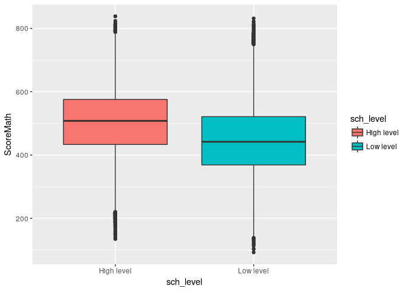

```r
subset(joined_stu_sch, !is.na(sch_level)) %>%
  ggplot(aes(x =sch_level,y=ScoreMath,fill=sch_level))+
  geom_boxplot()
```

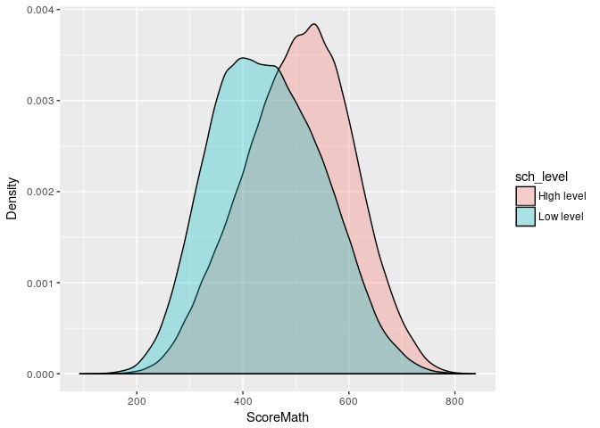

```r
subset(joined_stu_sch, !is.na(sch_level)) %>%
  ggplot(aes(x =ScoreMath,fill=sch_level),na.rm=T)+
  geom_density(alpha=0.3)+xlab("ScoreMath")+ylab("Density")
```

فرض صفر در اینجا آن است که میانگین نمرات دانش آموزان این دو گروه با هم تفاوت ندارد.

```r
joined_stu_sch %>% t.test(ScoreMath ~ sch_level,data=.)
```

```
##
##  Welch Two Sample t-test
##
## data:  ScoreMath by sch_level
## t = 141.28, df = 260880, p-value < 2.2e-16
## alternative hypothesis: true difference in means is not equal to 0
## 95 percent confidence interval:
##  55.65201 57.21790
## sample estimates:
## mean in group High level  mean in group Low level
##                 503.2366                 446.8017
```

سه گزاره جالب کشف کنید و ادعای خود را ثابت نمایید.

گزاره اول:

می خواهیم بررسی کنیم آیا انتظاری که دانش آموزان نسبت به تحصیلات آینده خود دارند چقدر در نمرات انها تاثیر دارد.

```r
bsg %>% select(idcntry,idstud,edu=bsbg08,math) %>%
  mutate(ScoreMath=(bsmmat01+bsmmat02+bsmmat03+bsmmat04+bsmmat05)/5) %>%
  mutate(edu_level = ifelse(edu <=3 , "Low_edu","High_edu")) -> stu_education
```

فرض صفر رد می شود و میزان انتظار دانش آموزان از آینده تحصیلی آنهاباعث تفاوت نمرات انها شده است.

```r
stu_education %>% t.test(ScoreMath ~ edu_level,data=.)
```

```
##
##  Welch Two Sample t-test
##
## data:  ScoreMath by edu_level
## t = 143.48, df = 98918, p-value < 2.2e-16
## alternative hypothesis: true difference in means is not equal to 0
## 95 percent confidence interval:
##  65.27505 67.08305
## sample estimates:
## mean in group High_edu  mean in group Low_edu
##               493.1850               427.0059
```

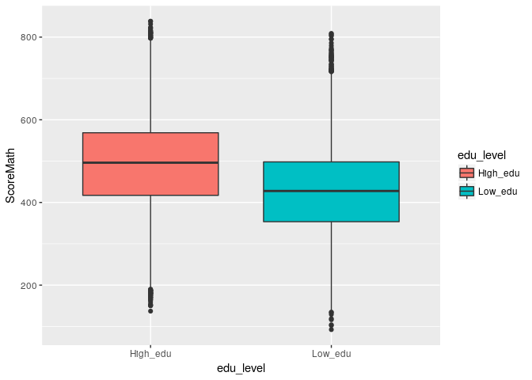

```r
subset(stu_education, !is.na(edu_level)) %>%
  ggplot(aes(x =edu_level,y=ScoreMath,fill=edu_level),na.rm=T)+
  geom_boxplot()
```

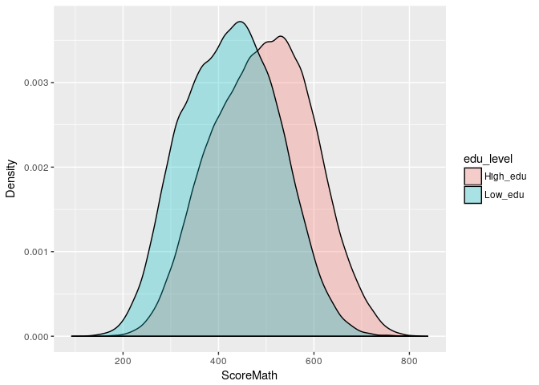

```r
subset(stu_education, !is.na(edu_level)) %>%
  ggplot(aes(x =ScoreMath,fill=edu_level),na.rm=T)+
  geom_density(alpha=0.3)+xlab("ScoreMath")+ylab("Density")
```

گزاره دوم:

در این بخش بررسی می کنیم تفاوت نمرات دانش آموزان شهر های پرجمعیت و کم جمعیت.

```r
idx = colnames(bcg) %>% grepl(x=.,pattern = "bcbg05a")
city_pop=colnames(bcg)[idx]

bcg %>% select(idcntry,idschool,city_pop=city_pop) -> school_area
```

```r
bsg %>%
  select(idcntry,idstud,idschool,math) -> stu_sch

stu_sch %>%
  inner_join(school_area,by=c("idcntry","idschool"))  -> joined_stu_sch
```

```r
joined_stu_sch %>%
  mutate(pop_level = ifelse(city_pop > 3 ,"Low pop","High pop")) -> joined_stu_sch

joined_stu_sch$ScoreMath=rowMeans(joined_stu_sch[,math],na.rm=T)
```

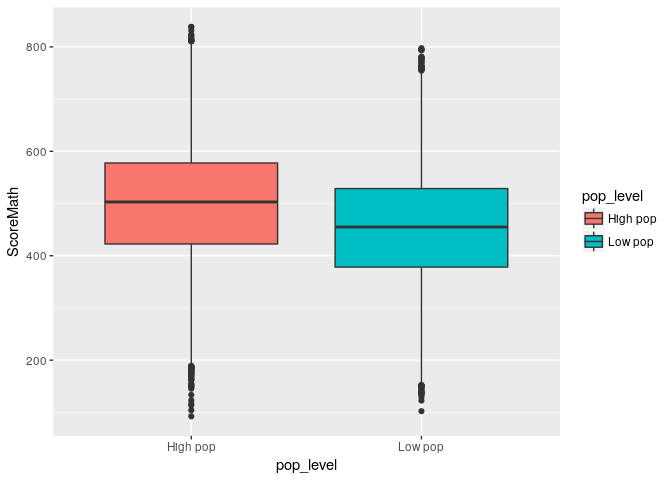

```r
subset(joined_stu_sch, !is.na(pop_level)) %>%
  ggplot(aes(x =pop_level,y=ScoreMath,fill=pop_level))+
  geom_boxplot()
```

فرض صفر رد می شود و نمرات دانش آموزان در شهر های پرجمعیت و کم جمعیت با هم تفاوت معنی دار دارند.

```r
joined_stu_sch %>% t.test(ScoreMath ~ pop_level,data=.)
```

```
##
##  Welch Two Sample t-test
##
## data:  ScoreMath by pop_level
## t = 114.65, df = 263900, p-value < 2.2e-16
## alternative hypothesis: true difference in means is not equal to 0
## 95 percent confidence interval:
##  45.50915 47.09219
## sample estimates:
## mean in group High pop  mean in group Low pop
##               499.8412               453.5405
```

گزاره سوم:

در این بخش ارتباط میزان علاقه دانش آموزان به ریاضیات و نمرات آن ها را بررسی می کنیم.

```r
interest=c("bsbm17a","bsbm17e","bsbm17f","bsbm17g","bsbm17i")

bsg %>% select(idcntry,idstud,interest,math) %>%
  mutate(ScoreMath=(bsmmat01+bsmmat02+bsmmat03+bsmmat04+bsmmat05)/5) -> stu_interest
stu_interest$math_interest=rowSums(stu_interest[,interest],na.rm=T)
```

```r
stu_interest %>%
  mutate(interest_level = ifelse(math_interest ==0  , NA,
                                 ifelse(math_interest > 10, "Low_interest","High_interest"))) -> stu_interest
```

فرض صفر در این جا آن است که میانگین نمرات دانش آموزان دو دسته علاقه مند و غیر علاقه مند تفاوت معنی دار ندارد.

فرض صفر را نمی توانیم رد کنیم.

```r
stu_interest %>% t.test(ScoreMath ~ interest_level,data=.)
```

```
##
##  Welch Two Sample t-test
##
## data:  ScoreMath by interest_level
## t = 1.1417, df = 270450, p-value = 0.2536
## alternative hypothesis: true difference in means is not equal to 0
## 95 percent confidence interval:
##  -0.3294736  1.2488016
## sample estimates:
## mean in group High_interest  mean in group Low_interest
##                    477.7795                    477.3198
```

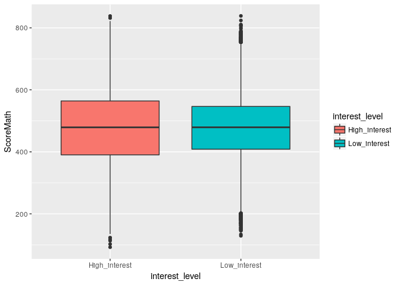

```r
subset(stu_interest, !is.na(interest_level)) %>%
  ggplot(aes(x =interest_level,y=ScoreMath,fill=interest_level),na.rm=T)+
  geom_boxplot()
```

```r
subset(stu_interest, !is.na(interest_level)) -> t

hchart(density(t$ScoreMath[t$interest_level=="Low_interest"]), area = TRUE, name="Low_interest") %>%
  hc_add_series(density(t$ScoreMath[t$interest_level=="High_interest"]), area = TRUE, name="High_interest")
```

[interactive chart not shown]